# Deep Dive #5

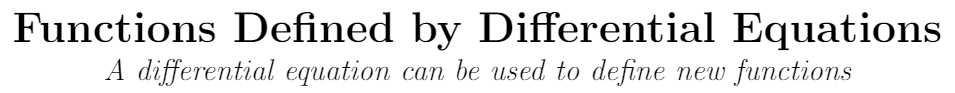

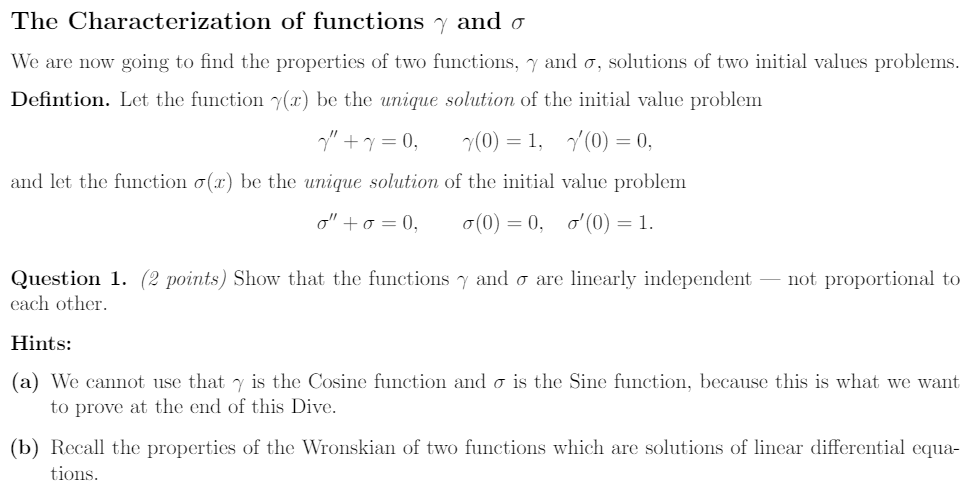

Properties of $\sigma $ and $\gamma$:

- Homogenous
- Constant coefficients
- Linear
- Defined for all initial data ($f(x)=1$ and $f(x)=0$ are continuous)
- $W_{\gamma\sigma}(0)=1$

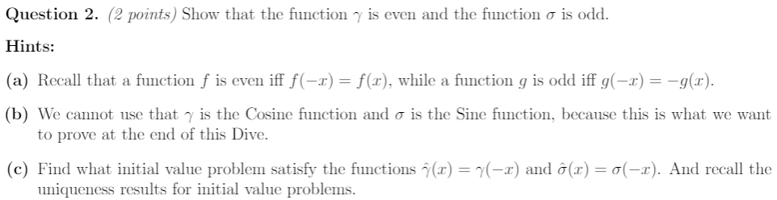

How do we do this? Define a function $f(x)$ that (1) has the same initial values as $\gamma$ or $\sigma$, and (2) satisfies the orignal differential equation $f''+f=0$.

$\gamma:$ Choose $f$ s.t. $f(t)=\gamma(-t)$

(1) Show initial values are `equivalent

$$ f(0)=\gamma(-0) = \gamma(0)=1\ \checkmark \\ f'(t) = \frac{d}{dt}\gamma(-t)=-\gamma'(-t) \\ f'(0) = -\gamma'(-0)= -\gamma'(0) = -0\ \checkmark $$

(2) Show $f(t)$ statisfies $\gamma''+\gamma=0$ $$ f''(t) = \frac{d}{dt}-\gamma'(-t) = \gamma''(-t) \\ \gamma''(0) + \gamma(0)=0 \implies \gamma''(0) = -1 \\ f''(0) = \gamma''(-0) = \gamma''(0) = -1 \\ f''(0)+f(0)=-1 + 1 = 0 \ \checkmark $$

Since $f$ has the same initial conditions as $\gamma$ and agrees with the differential equation which $\gamma$ is a solution of, $f$ and $\gamma$ are equivalent unique solutions by the existence uniqueness theorem

$\sigma: $ Choose $g$ s.t. $g(t) = -\sigma(-t)$

(1) Show initial values are equivalent

$$ g(0) = \sigma(-0) = \sigma(0) = 0 \ \checkmark \\ g'(t) = \frac{d}{dt} -\sigma(-t) = \sigma'(-t) \\ g'(0) = \sigma'(-0) = \sigma'(0)= 1\ \checkmark $$

(2) Show $g(t)$ satisfies $\sigma''+\sigma=0$

$$ g''(t) = \frac{d}{dt}-\sigma'(-t) = \sigma''(-t) \\ \sigma''(0) + \sigma(0)=0 \implies \sigma''(0) = 0 \\ g''(0) = \sigma''(-0) = \sigma''(0) = 0 \\ g''(0)+f(0)=0 + 0 = 0 \ \checkmark $$

Since $g$ has the same initial conditions as $\sigma$ and agrees with the differential equation which $\sigma$ is a solution of, $f$ and $\sigma$ are equivalent unique solutions by the existence uniqueness theorem

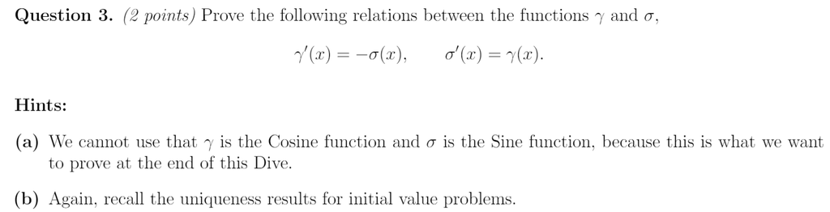

Let us consider the initial values of $-\gamma'(x)$, hopefully they'll be the same as $\sigma(x)$

$$-\gamma'(0)=-0=0 \\ \frac{d}{dx}-\gamma'(x) = -\gamma''(x)=-(-1)=1 $$

How fortunate! Now all we need is for it to satisfy the original differential eqation and we'll know it is the same as the unique solution $\sigma(x)$

$$ \gamma = -\gamma'' \implies (\gamma)' = (-\gamma'')'\\ \frac{d^2}{dx^2}(-\gamma') +(- \gamma')=0\ \checkmark $$

Thus these equations are the same unique solution to the original differential equation

From this the next proof is quite easy. Take the derivative of our previous result

$\gamma''(x)=-\sigma'(x)=-\gamma(x) \implies \sigma'(x)=\gamma(x)$

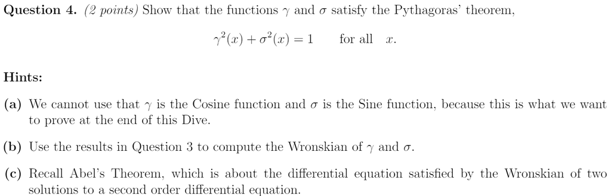

Lets start by computing the Wronskian of $\gamma$ and $\sigma$

$W_{\gamma\sigma}=\gamma\sigma'-\sigma\gamma'=\gamma\gamma+\sigma\sigma $

Since we computed in step 1 that $W(0)=1$ and according to Abel's theorem W'=0 for SOLDEs with no f' component, it is a constant function $W(x)=1$ and thus $\gamma^2(x)+\sigma^2(x)=1\ \forall x$

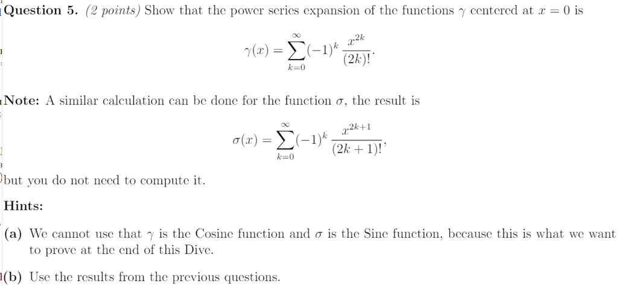

Okay lets do it.

We know $\gamma(0) = 1,\gamma'(0)=0,$ and $\gamma''(0)=-1$. We can take the derivative continuously. $$\gamma(0)=-\gamma''(0)\implies \gamma'(0)=-\gamma'''(0)$$

Thus the sign of $\gamma^{(2n)}$ flips continuously, while $\gamma^{2n+1}=0$. The taylor expansion of $\gamma$ becomes $$\gamma(x)=\sum_{k=0}^\infty (-1)^k\frac{x^{2k}}{(2k!)}$$

done! yaya!!!